# 04-procesamiento-flujos-tarea

Soledad Perez

22/2/2019

### Tarea

- Resuelve los dos ejercicios pendientes (uno en filtro de Bloom, otro en las sección de muestras uniformemente distribuidas

#### Filtro de Bloom

- Encuentra alguna palabra del español que no esté en el filtro (por ejemplo una de español en México). Agrégala al filtro y verifica que es detectada como positiva. Busca una posible manera incorrecta de escribirla y prueba la función de arriba de sugerencias.

Diccionario

```r
diccionario <- read_csv("../datos/diccionario/es_dic.txt", col_names = FALSE) %>%
          pluck("X1")
# nota: el encoding del diccionario debe ser utf-8
# diccionario <- iconv(diccionario, to = "UTF-8")
m <- length(diccionario)
m
```

```
## [1] 247049
```

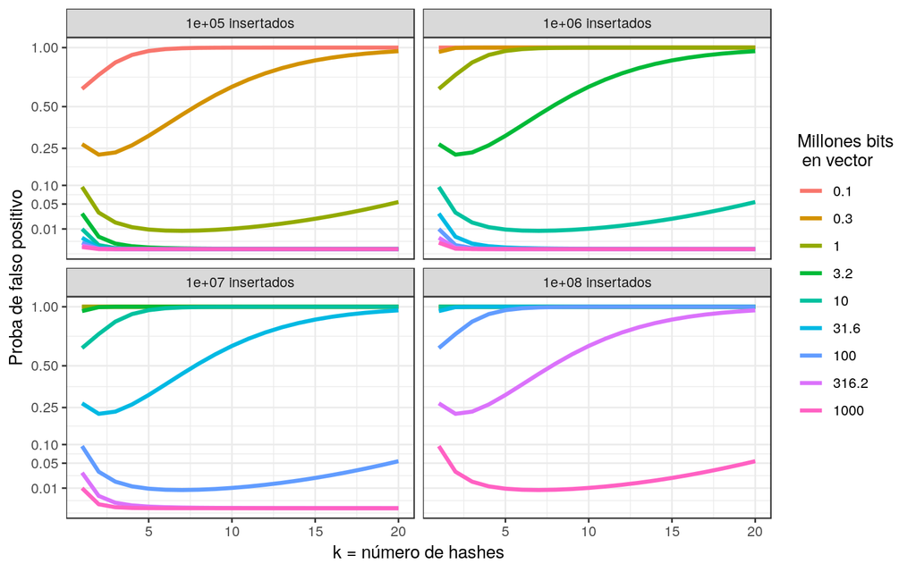

```r
tasa_fp <- function(n, s, k) {
    (1 - (1 - (1 / n)) ^ (k * s)) ^ k
}
df <- expand.grid(list(s = c(1e5, 1e6, 1e7, 1e8),
        k = seq(1, 20),
        n = 10 ^ seq(5, 9, by = 0.5))) %>%
      mutate(mill_bits = round(n/1e6, 1)) %>%
      mutate(tasa_falsos_p = tasa_fp(n, s, k)) %>%
      mutate(s_str = paste0(s, ' insertados'))


ggplot(df, aes(x = k, y = tasa_falsos_p,
  colour = factor(mill_bits), group = mill_bits)) +
  geom_line(size = 1.2) +
  facet_wrap(~s_str) +
  labs(x = "k = número de hashes",
       y =  "Proba de falso positivo",
       colour = "Millones bits \n en vector") +
  scale_y_sqrt(breaks = c(0.01,0.05,0.1,0.25,0.5,1))
```

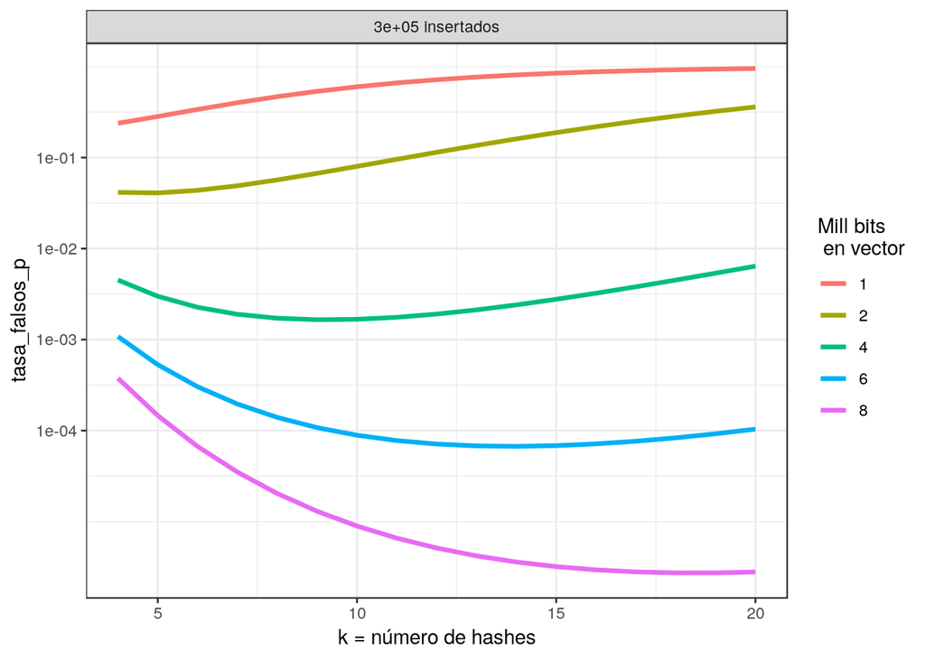

```r
df <- expand.grid(list(s = 300000,
                  k = seq(4, 20),
                  n = c(1e6, 2e6, 4e6, 6e6, 8e6)
                  )) %>%
      mutate(millones_bits = (n/1e6)) %>%
      mutate(tasa_falsos_p = tasa_fp(n, s, k)) %>%
      mutate(s_str = paste0(s, ' insertados'))


ggplot(df, aes(x = k, y = tasa_falsos_p,
               colour=factor(millones_bits), group=millones_bits)) +
               geom_line(size=1.2) +
               facet_wrap(~s_str) +
               labs(x="k = número de hashes",
                    colour = "Mill bits \n en vector") +
               scale_y_log10(breaks= c(0.0001, 0.001, 0.01, 0.1))
```

Vector de 8 millones de bits con unos 6 hashes. Nuestra estimación de falsos positivos con 6 hashes es de

```r
n <- 8e6
tasa_fp(n = n, s = 250000, k = 6)
```

```
## [1] 2.497659e-05
```

Ahora necesitamos nuestras funciones hash escogidas al azar. Podemos usar el algoritmo [xxhash32](https://github.com/Cyan4973/xxHash), por ejemplo:

```r
library(digest)
set.seed(18823)
hash_generator <- function(k = 1, n){
  seeds <- sample.int(652346, k)
  hasher <- function(x){
    sapply(seeds, function(s){
      # en digest, serialize puede ser false, pues trabajamos con cadenas
      # la salida de xxhash32 son 8 caracteres hexadecimales, pero
      # solo tomamos 7 para poder convertir a un entero
      sub_str <- substr(digest::digest(x, "xxhash32",
        serialize = FALSE, seed = s), 1, 7)
      strtoi(sub_str, base = 16L) %% n + 1 #Se convirte a entero
    })
  }
  hasher
}
hashes <- hash_generator(5, n)
```

Implementación del fitro de Bloom:

```r
filtro_bloom <- function(num_hashes, n){
    v <- raw(n)
    hashes <- hash_generator(num_hashes, n)
    insertar <- function(x){
        v[hashes(x)] <<- as.raw(1) ## se hace <<- para hacer la asignacion en la variable v
        ## de la funcion arriba
        x <- iconv(x, "utf-8")
        v[hashes(x)] <<- as.raw(1)
    }
    en_filtro <- function(x){

        all(as.logical(v[hashes(x)]))
    }
    vec <- function() v
    filtro <- list(insertar = insertar, en_filtro = en_filtro, vec = vec)
    filtro
}
```

Ahora creamos el filtro e insertamos los elementos del diccionario:

```r
# crear filtro
set.seed(812)
filtro_b <- filtro_bloom(num_hashes = 6, n = 8e6) ## Original 4e6
# insertar palabras de diccionario
system.time(
    for(i in seq_along(diccionario)){
        filtro_b$insertar(diccionario[i])
    })
```

```
##    user  system elapsed
## 262.480   0.010 262.565
```

El tamaño del filtro es de

```r
format(object.size(filtro_b$vec()), units = "Mb")
```

```
## [1] "7.6 Mb"
```

Una palabra que no está en el diccionario es:

```r
filtro_b$en_filtro("botana")
```

```
## [1] TRUE
```

```r
filtro_b$en_filtro("botanear")
```

```
## [1] FALSE
```

```r
filtro_b$en_filtro("chipotle")
```

```
## [1] FALSE
```

```r
filtro_b$en_filtro("vocho")
```

```
## [1] FALSE
```

```r
filtro_b$en_filtro("apapac")
```

```
## [1] FALSE
```

Insertamos las palabras

```r
filtro_b$insertar("botanear")
filtro_b$insertar("chipotle")
```

Verificamos que esté la palabra **botanear**

```r
filtro_b$en_filtro("botana")
```

```
## [1] TRUE
```

```r
filtro_b$en_filtro("botanear")
```

```
## [1] TRUE
```

```r
filtro_b$en_filtro("chipotle")
```

```
## [1] TRUE
```

- Prueba usando un vector de bits mucho más chico (por ejemplo de 500 mil bits). ¿Qué tasa de falsos positivos obtienes?

```r
# crear filtro
set.seed(536)
filtro_b_2 <- filtro_bloom(num_hashes = 6, n = 5e5) ## Original 4e6
# insertar palabras de diccionario
system.time(
    for(i in seq_along(diccionario)){
        filtro_b$insertar(diccionario[i])
    })
```

```
##    user  system elapsed
## 265.630   0.050 265.833
```

Tasa de falsos positivos

```r
n <- 5e5
tasa_fp(n = n, s = 250000, k = 6)
```

```
## [1] 0.7360817
```

```r
filtro_b_2$en_filtro("botana") # botana si estaba cuando el vector era de 8e6
```

```
## [1] FALSE
```

```r
filtro_b_2$en_filtro("botanear")
```

```
## [1] FALSE
```

```r
filtro_b_2$en_filtro("chipotle")
```

```
## [1] FALSE
```

```r
filtro_b_2$en_filtro("vocho")
```

```
## [1] FALSE
```

```r
filtro_b_2$en_filtro("apapac")
```

```
## [1] FALSE
```

Sugerencias de corrección

```r
generar_dist_1 <- function(palabra){
  caracteres <- c(letters, 'á', 'é', 'í', 'ó', 'ú', 'ñ')
  pares <- lapply(0:(nchar(palabra)), function(i){
    c(str_sub(palabra, 1, i), str_sub(palabra, i+1, nchar(palabra)))
  })
  eliminaciones <- pares %>% map(function(x){ paste0(x[1], str_sub(x[2],2,-1))})
  sustituciones <- pares %>% map(function(x)
      map(caracteres, function(car){
    paste0(x[1], car, str_sub(x[2], 2 ,-1))
  })) %>% flatten
  inserciones <- pares %>% map(function(x){
    map(caracteres, function(car) paste0(x[1], car, x[2]))
  }) %>% flatten
  transposiciones <- pares %>% map(function(x){
    paste0(x[1], str_sub(x[2],2,2), str_sub(x[2],1,1), str_sub(x[2],3,-1))
  })
  c(eliminaciones, sustituciones, transposiciones, inserciones) %>% unlist
}
```

```r
generar_dist_1('bottana') %>% keep(filtro_b$en_filtro)
```

```
## [1] "botana" "botana"
```

```r
generar_dist_1('chipotle') %>% keep(filtro_b$en_filtro)
```

```
##  [1] "chipotle" "chipotle" "chipotle" "chipotle" "chipotle" "chipotle"
##  [7] "chipotle" "chipotle" "chipotle" "chipotle" "chipotle"
```

#### Hyperloglog

- Repetir la estimación del hyperloglog del ejemplo de clase aumentando a 250-500 mil elementos distintos. Puedes utilizar la implementación de spark. ¿Qué errror relativo obtuviste? Nota: puedes usar la implementación en R que vimos en clase, pero ojo: las funciones hash que utilizamos son relativamente lentas.

Consideramos una función hash (para cadenas):

```r
hash_gen <- function(seed){
  function(x){
    hash_32 <- digest::digest(x, 'xxhash32', serialize = FALSE, seed = seed)
    # Covertimos a bits, tomando de dos en dos:
    # Esta implementación es lenta
    sapply(seq(1, nchar(hash_32), 2), function(x) substr(hash_32, x, x+1)) %>%
        strtoi(16L) %>% as.raw %>% rawToBits()
  }
}
set.seed(5451)
hash_1 <- hash_gen(seed = 123)
hash_2 <- hash_gen(seed = 564)
```

Funcion para contar numero de ceros

```r
tail_length <- function(bits){
  bits %>% which.max - 1
}
hash_1("7yya4071872aa") %>% tail_length
```

```
## [1] 5
```

```r
cubeta_bits <- 5
m <- 2^cubeta_bits
tail_length_lead <- function(bits){
  bits[-c(1:cubeta_bits)] %>% which.max %>% as.integer
}
hash_1("7yya40787")
```

```
##  [1] 01 01 01 00 00 00 01 01 00 01 00 00 01 00 00 01 01 01 01 00 00 00 00
## [24] 00 00 01 00 01 00 00 01 01
```

```r
hash_1("7yya40787") %>% tail_length_lead
```

```
## [1] 2
```

```r
cubeta <- function(bits){
  paste0(as.character(bits[1:cubeta_bits]), collapse = "")
}
hash_1("7yya40787") %>% cubeta
```

```
## [1] "0101010000"
```

Simulamos unos datos y calculamos la cubeta para cada dato:

```r
n <- 500000
df <- data_frame(num_distintos = 1:n) %>%
      mutate(id = as.character(sample.int(52345678, n, replace = FALSE))) %>%
      mutate(hash = map(id, hash_1)) %>%
      mutate(cubeta = map_chr(hash, cubeta))
df
```

```
## # A tibble: 500,000 x 4
##    num_distintos id       hash       cubeta
##            <int> <chr>    <list>     <chr>
##  1             1 12638327 <raw [32]> 0000000000
##  2             2 32768794 <raw [32]> 0001010101
##  3             3 35769702 <raw [32]> 0100000000
##  4             4 49696296 <raw [32]> 0000000101
##  5             5 25500838 <raw [32]> 0001000001
##  6             6 21102554 <raw [32]> 0000010000
##  7             7 23517787 <raw [32]> 0000010100
##  8             8 46271047 <raw [32]> 0000010100
##  9             9 23945948 <raw [32]> 0000000100
## 10            10 25704509 <raw [32]> 0001010101
## # ... with 499,990 more rows
```

Y calculamos la longitud de la cola:

```r
df <- df %>% mutate(tail = map_int(hash, tail_length_lead))
df
```

```
## # A tibble: 500,000 x 5
##    num_distintos id       hash       cubeta      tail
##            <int> <chr>    <list>     <chr>      <int>
##  1             1 12638327 <raw [32]> 0000000000     1
##  2             2 32768794 <raw [32]> 0001010101     2
##  3             3 35769702 <raw [32]> 0100000000     2
##  4             4 49696296 <raw [32]> 0000000101     2
##  5             5 25500838 <raw [32]> 0001000001     6
##  6             6 21102554 <raw [32]> 0000010000     1
##  7             7 23517787 <raw [32]> 0000010100     1
##  8             8 46271047 <raw [32]> 0000010100     1
##  9             9 23945948 <raw [32]> 0000000100     3
## 10            10 25704509 <raw [32]> 0001010101     2
## # ... with 499,990 more rows
```

Ahora vemos cómo calcular nuestra estimación. cuando hay 50 mil distintos, calculamos máximo por cubeta

```r
resumen_50 <- df %>% filter(num_distintos <= 50000) %>%
    group_by(cubeta) %>%
    summarise(tail_max = max(tail))
resumen_50
```

```
## # A tibble: 32 x 2
##    cubeta     tail_max
##    <chr>         <dbl>
##  1 0000000000       12
##  2 0000000001       14
##  3 0000000100       10
##  4 0000000101       11
##  5 0000010000       11
##  6 0000010001       12
##  7 0000010100       10
##  8 0000010101       10
##  9 0001000000       12
## 10 0001000001       12
## # ... with 22 more rows
```

Y luego calculamos la media armónica y reescalamos para obtener:

```r
armonica <- function(x) 1/mean(1/x)
0.72 * m * armonica(2 ^ resumen_50$tail_max)
```

```
## [1] 50804.63
```

Y esta es nuestra estimación de únicos en el momento que el verdadero valor es igual a 50000.

Podemos ver cómo se desempeña la estimación conforme nuevos únicos van llegando (el siguiente cálculo son necesarias algunas manipulaciones para poder calcular el estado del estimador a cada momento);

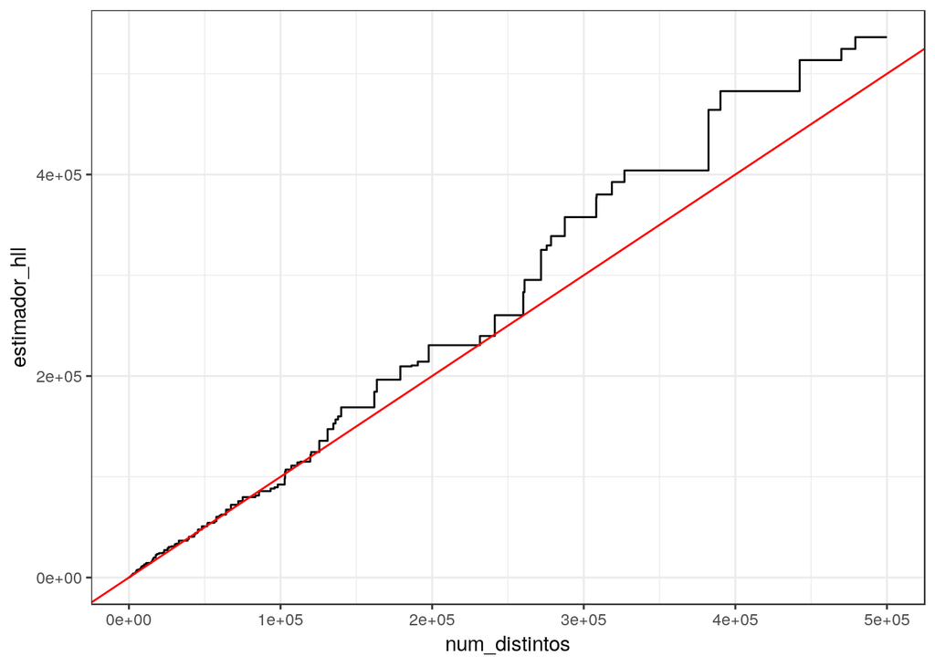

```r
res <- df %>% spread(cubeta, tail, fill = 0) %>%
        gather(cubeta, tail, -num_distintos, -id, -hash) %>%
        select(num_distintos, cubeta, tail)
res_2 <- res %>%
      group_by(cubeta) %>%
      arrange(num_distintos) %>%
      mutate(tail_max = cummax(tail)) %>%
      group_by(num_distintos) %>%
      summarise(estimador_hll = 0.72*(m*armonica(2^tail_max)))
ggplot(res_2 %>% filter(num_distintos > 100),
       aes(x = num_distintos, y = estimador_hll)) + geom_line() +
  geom_abline(slope = 1, colour ='red')
```

Finalmente, examinamos el error relativo:

```r
quantile(1 - res_2$estimador_hll/res_2$num_distintos, probs=c(0.1, 0.5, .9))
```

```
##          10%          50%          90%
## -0.208142051 -0.111216246 -0.002021158
```

```r
#library(sparklyr)
#sc <- spark_connect(master = "local") # esto normalmente no lo hacemos desde R
#df_tbl <- copy_to(sc, df %>% select(num_distintos, id))
#df_tbl %>%
#  summarise(unicos_hll = approx_count_distinct(id)) # error estándar relativo 0.05
```